# Customer Management Model Framework

Derek Fulton, Anthony Clark, Kenneth Frejie

### Aims of this report

- **Introduce and explain the customer management model, a risk-sloping model that divides customers into risk deciles**
- **Explore direct applications of model to cohorts of current customers, starting with downpayment portion modification**
- **Propose a simulation framework for a current portfolio given predictions on dq0 and assumptions about customer churn**

## The Transition from ACH to Stripe

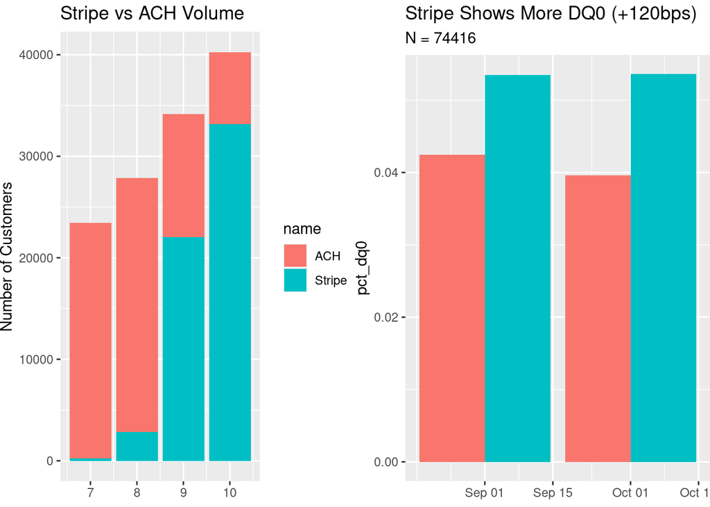

We see above that by since September 2021 Flex process half of its payments with Stripe. However due to the exponential user growth, we will have a much larger sample of Stripe payments by Q1 2022. Note also that Stripe shows higher DQ0 rates, likely because the riskiest ACH customers are also prone to missing their down payments, rendering them absent in our database (*scheduled_charge_extended* in BigQuery). So while Stripe DQ0 appears higher in this data (to the tune of roughly 120bp), we still do expect Stripe to help with DQ0 rates in the long-term due to the instantaneous nature of debit card payments. **This improved data fidelity may pave the way to more robust and reliable analytics, with future analysis run on “Stripe-only” datasets.**

The tradeoff for this improvement is, obviously, the Stripe fee that we currently eat. This fee will be factored into future PnL simulations.

### Effect of Transition on Model Development

For the purposes of this report, we have about 250k data points (a data point being a customer-month). Of these, about 60k are from Stripe. These 60k Stripe data points are substantial, and as mentioned above will grow rapidly in the coming months, but the models presented in the next section have still heavily relied on data from the ACH days. It is important to be mindful that using analytics from the ACH days to make predictions about Stripe payments in a young business with such high customer churn, seasonality and exponential user growth in an environment of tapering of government income support and the risk of rate hikes may be tantamount to mowing an entire lawn with a weedwhacker.

## Model Design

The Customer Management Model is largely based on Flexscore2. However, the there are two key assets we now have that are not available at the time of Flexscore2-based underwriting:

- The number of previous rent-months they have paid with Flex
- Whether or not they have ever DQ0’ed with Flex

Therefore we include the following independent variables in our design matrix:

- previous_dq
- months_oldest_revolving_trade
- months_oldest_installment_trade
- num_inquiries_l90d
- revolving_trades_util
- **previous_bills_paid**
- **vantage30_score**

The dependent variable which we aim to predict is dq0. While only dq180 is considered a true default, we don’t have enough performance history to use a six-month window to generate dependent variable targets.

### Independent Variable Distributions

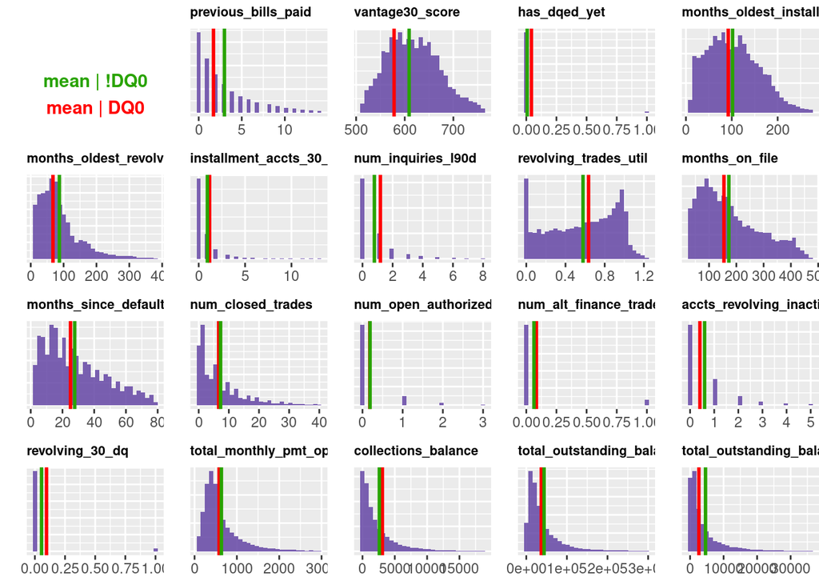

> **A note on previous_bills_paid**

> In terms of predictive power, previous_bills_paid appears to be neck-and-neck with vantage30_score. However this is likely an artifact of survivor bias, as dq0 customers are highly likely to churn. It is still our most useful feature, in fact vantage30_score and previous_bills_paid alone recover nearly all of the model’s predictive power (in a log-loss sense).

## Train/Test Split

There are two ways to split the training and testing sets:

A problem with splitting at random is that most of the train and test sets are ACH payments, yet nearly all future bills will be Debit (Stripe). In contrast, a benefit of splitting at random is that a certain degree of seasonality inherent to the consumer lending process is spoken for.

The problem with splitting by month, testing only on September, October or both, is that we are essentially training in the ACH world and testing in the Stripe world. On the bright side, since we know that Stripe payments show roughly 120bs more DQ0 we can simply shift the predicted DQ0 up by roughly this amount and should see a good match. This “bias” term remains consistent. By the new year there will be enough Stripe data to conduct entire analyses on Stripe data only.

### Model Results

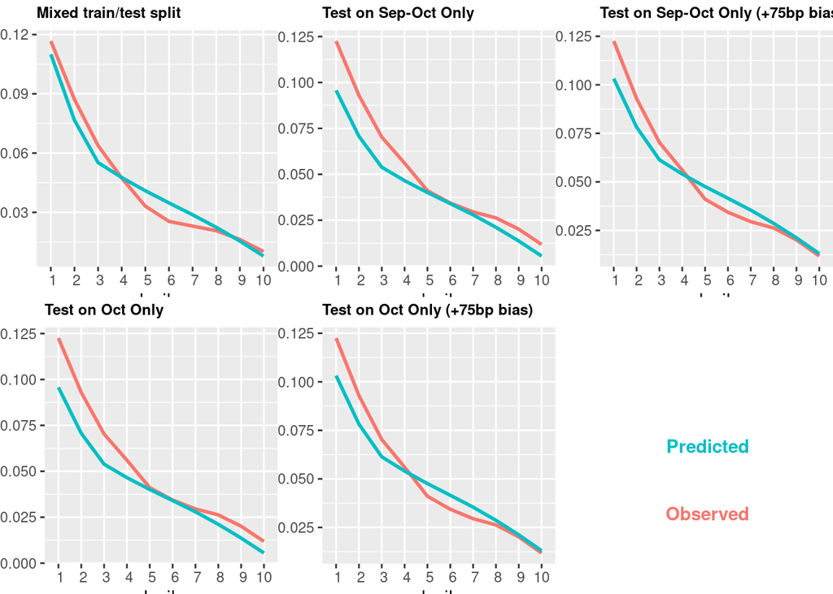

Note that although the Stripe dq0 rate is roughly 120bps above the ACH dq0, a bias of only 75bp was applied. This is because there are still some ACH payments in Sep/Oct so the full 120bps would be overshoot.

### PnL Simulation Framework

Let $Y$ be a random variable giving the net revenue for a given customer-month, $P$ be the predicted probability of DQ0, $R$ be the customer’s total rent bill, $d$ be the customer’s downpayment responsibility (and $1-d$ the amount we front). The expected value of $y$ is

$$\begin{equation}
\textbf{E[}Y\textbf{]} = 20 - PR(1-d),
\end{equation}$$

and the observed monthly value is

$$\begin{equation}
Y = 20 - IR(1-d)
\end{equation}$$

where $0 <= d <= 1$ and $I=0$ if they paid back their loan and $I=1$ if they DQ0’ed. Applying this to a cohort of $n$ customers on a decile basis is straightforward and will allow us compute the effect of assigning each decile $i$ a unique downpayment requirement $d_i$, potentially lowering this requirement for low-risk customers. **Assigning different $d_i$ values to different deciles, and simulating the effect on the portfolio’s risk profile, is clear next step. This requires, however, assumptions about how much the high-decile customers will “like” this reduced downpayment and become less likely to churn.**

Note also that we do not yet factor in cure rate, $C$. $C$ is the bridge between DQ0 (the sole focus of this model) and DQ180, the dreaded default in an accounting sense. Factoring in cure rate the expected value of net revenue for a customer would become

Cure rate will be implemented in the next version of the customer management model.

## Next steps

- Test this model on the November and December customer cohorts
- Use these equations to compute net SVA on each decile and each customer
- Run simulations to predict net PnL on the entire portfolio, testing out different downpayment requirements and making an assumption for the corresponding effects on customer churn
- Implement the strategies discovered in the simulations to improve the portfolio in Q1 2022